# Exploring the BRFSS data

## Setup

### Load packages

```r
library(ggplot2)
library(dplyr)
```

### Load data

```r
load("brfss2013.RData")
```

## Part 1: Data

Behavorial Risk Factor Surveillance System(BRFSS) is an initiation of Centers for Diseases Control and Prevention(CDC), is aimed for a cross-sectional telephone survey that state health departments conduct monthly telephones survey through landline and cellular telephones with their standardized questioners.Collection of data is done according to the BRFSS protocols. In general surveys are conducted through 20% interviews on weekdays and 80% on weekends.

As BRFSS is a survey related to health so that’s questioners was developed in collaboration between CDC and health departments in each state and in this survey some protocols like: -> All states ask the core questions without modification. -> An eligible household is defined as a housing unit. -> Eligible household members include all related adults(more than 18 years)

We can only apply correlation as because BRFSS survey is oprtional not experimental.

## Part 2: Research questions

**Research quesion 1:** Try to find out a correlation between the level of income and smokers who smokes. One with high level of income smokes because of his high level of stress.what will be its effect on general health.

**Research quesion 2:** Finding a correlation between the level of income and having good health. it will tell us if level of income is high then individual has stress or not.

**Research quesion 3:** We try to find a correlation between a general good health and mental health. A person having general good health also has a good mental health.

## Part 3: Exploratory data analysis

**Research quesion 1:**

```r
#Relation in between income & Smoking
EDA1 <- select(brfss2013, income2, sex, smoke100,  genhlth) %>%
  filter(!is.na(income2), !is.na(sex), !is.na(genhlth))

EDA1 %>%
  group_by(income2)%>%
  summary(count=n())
```

```
##               income2           sex         smoke100           genhlth
##  $75,000 or more  :115659   Male  :177547   Yes :187368   Excellent: 74253
##  Less than $75,000: 65102   Female:241372   No  :221971   Very good:138247
##  Less than $50,000: 61319                   NA's:  9580   Good     :127701
##  Less than $35,000: 48687                                 Fair     : 55602
##  Less than $25,000: 41563                                 Poor     : 23116
##  Less than $20,000: 34705
##  (Other)          : 51884
```

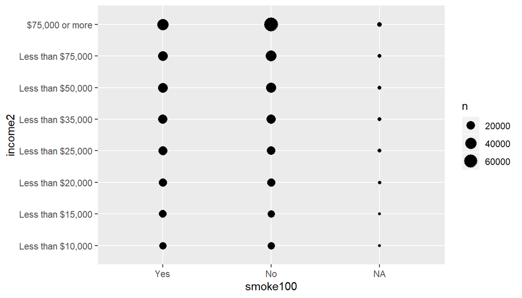

```r
ggplot(data=EDA1, aes(smoke100, income2))+
  geom_count()
```

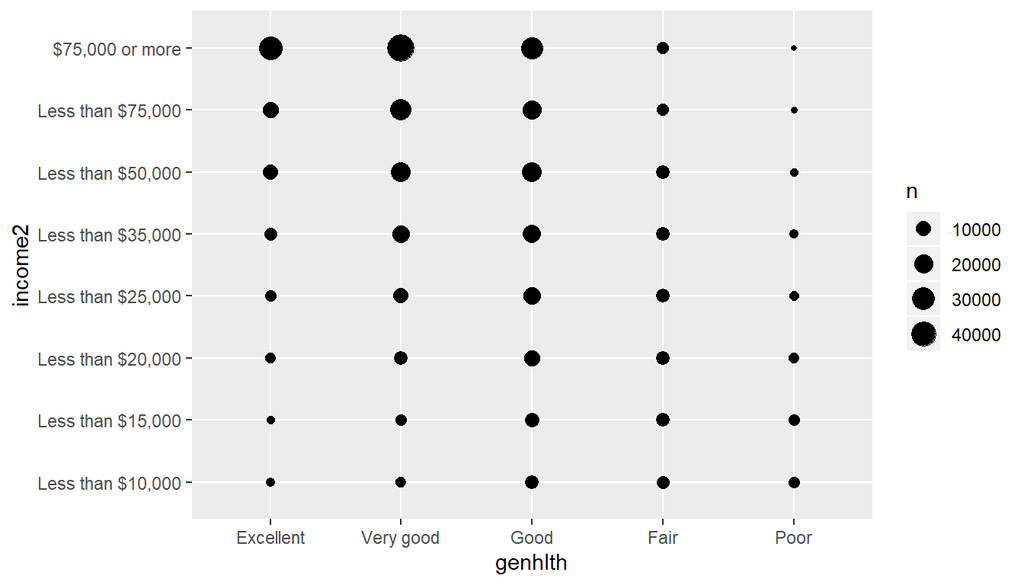

```r
ggplot(data=EDA1, aes(genhlth, income2))+
  geom_count()
```

**Research quesion 2:**

```r
EDA2 <- select(brfss2013, income2, sex, genhlth) %>%
  filter(!is.na(income2), !is.na(sex), !is.na(genhlth))
EDA2 %>%
  group_by(income2) %>%
  summary(count=n())
```

```
##               income2           sex              genhlth
##  $75,000 or more  :115659   Male  :177547   Excellent: 74253
##  Less than $75,000: 65102   Female:241372   Very good:138247
##  Less than $50,000: 61319                   Good     :127701
##  Less than $35,000: 48687                   Fair     : 55602
##  Less than $25,000: 41563                   Poor     : 23116
##  Less than $20,000: 34705
##  (Other)          : 51884
```

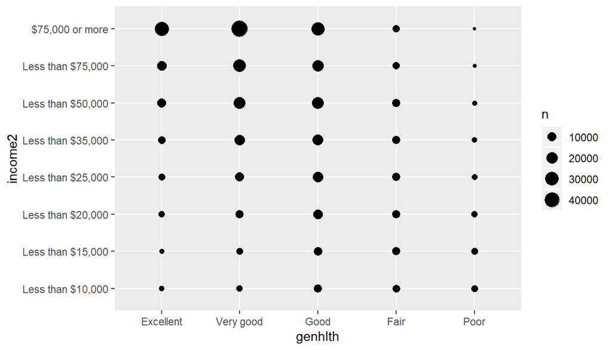

```r
ggplot(data=EDA2, aes(genhlth, income2))+
  geom_count()
```

–>In visualization of general health and income level results has variation.

**Research quesion 3:**

```r
EDA3 <- select(brfss2013, genhlth, sex, menthlth) %>%
  filter(!is.na(genhlth), !is.na(sex), !is.na(menthlth))

EDA3 %>%
  group_by(genhlth) %>%
  summary(count=n())
```

```
##       genhlth           sex            menthlth
##  Excellent: 84790   Male  :197358   Min.   : 0.000
##  Very good:157395   Female:284129   1st Qu.: 0.000
##  Good     :147912                   Median : 0.000
##  Fair     : 64687                   Mean   : 3.366
##  Poor     : 26703                   3rd Qu.: 2.000
##                                     Max.   :30.000
```

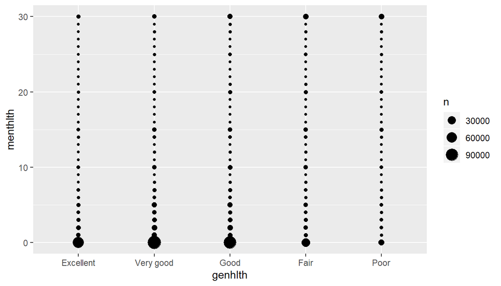

```r
ggplot(data=EDA3, aes(genhlth, menthlth))+
  geom_count()
```

–>In visualization of EDA3 result has variation in having good mental health with good health.